# Carbon patterns in anthropogenic sealed urban soils

A pilot study

Mariana Dos Santos Moreno<sup>a,b</sup>, Moreen Willaredt<sup>c,d</sup>, Pablo Pastén<sup>b,e</sup>, Pilar Gil<sup>a</sup>, Alejandra Vega<sup>b</sup>, Sara E. Acevedo<sup>a,b</sup>

## Urban expansion and the carbon cycle

- Urban expansion has transformed natural soils and disrupted biogeochemical flows (O’Riordan et al., 2021);
- Soil sealing (pavement, gray infrastructure) is one of the most discussed forms of urban soil degradation (Lehmann, 2006);
- Sealing interrupts natural carbon (C) inputs - expected gradual decrease and stabilization of soil C stocks.

## Contrasting effects of sealing

- Soil sealing can also:

- Reduces organic matter (OM) decomposition rate (Lu et al., 2020);
- Lowers microbial biomass;
- Decreases soil respiration (Pereira et al., 2021);
- Hypothesis in the literature: C may actually accumulate beneath sealed surfaces.

## How’s the C dynamic in sealed soils?

- Urban sealed soils show ambiguous C distribution (O’Riordan et al., 2021);
- Partial evidence suggests urban C reservoirs may exist, but but they remain unquantified;
- In South America specifically, there is a lack of data on how soil sealing affects soil quality attributes, including C concentration (Liu et al., 2026);
- This limits accurate urban C budget modeling and climate change mitigation planning.

## Central hypothesis

> The vertical patterns of C differ between sealed and unsealed soils.
- Understanding this is key to determining whether sealed urban soils are an underestimated C reservoir.

## Objectives

- Quantify the vertical gradients of total C in 3 sealed and 2 surrounding unsealed soils located in urban greenspaces of Santiago, Chile;
- Three depths: 0-10, 10-20, and 20-30 cm;
- To determine whether sealing drives C accumulation or depletion along the soil profile.

## Methods

**Sampling sites**

- Rio-pav (paved soils) - Bellas Artes, Santiago, Chile - 3 sites;
- Rio-ug (urban green space soils) - Cerro Santa Lucía and Parque Forestal, Santiago, Chile - 2 sites.

**Analyses**

- Soil samples: air-dried, sieved (< 2 mm), analyzed in triplicate;
- Texture: determined after OM removal (H2O2, 30%), PARIO sensor;
- pH: measured at 1:2.5 ratio;
- Total C: high-temperature catalytic combustion (TOC-L, Shimadzu, Japan).

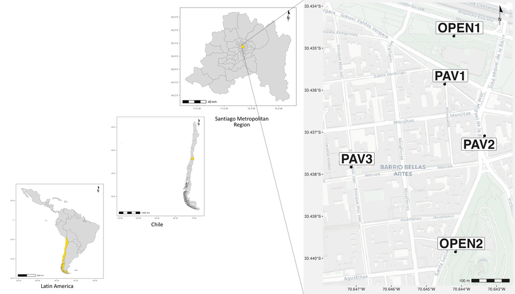

## Results

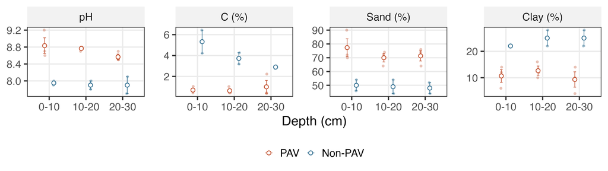

## Results - Chilean soils background

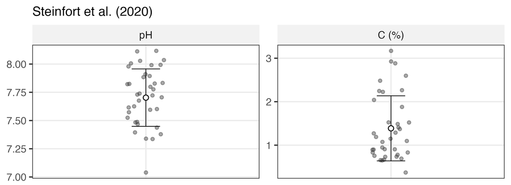

## References

Lehmann, A. (2006). Technosols and other proposals on urban soils for the WRB (World Reference Base for Soil Resources). *Int. Agrophys., 20*(2), 129–134

Liu, H., Tan, X., Xiao, R., Tian, P., He, X., Wang, J., & Li, Y. (2026). Global patterns of urban soil degradation: Revealing the impacts of urbanization on natural and sealed urban soils. *Ecological Indicators*, *185*, 114755. https://doi.org/10.1016/j.ecolind.2026.114755

Lu, C., Kotze, D. J., & Setälä, H. M. (2020). Soil sealing causes substantial losses in C and N storage in urban soils under cool climate. *Science of the Total Environment*, *725*, 138369. https://doi.org/10.1016/j.scitotenv.2020.138369

O’Riordan, R., Davies, J., Stevens, C., and Quinton, J. N. (2020). The effects of sealing on urban soil carbon and nutrients, *SOIL*, *7*, 661–675, https://doi.org/10.5194/soil-7-661-2021

Pereira, M.C., O’Riordan, R. & Stevens, C. 2021. Urban soil microbial community and microbial-related carbon storage are severely limited by sealing. *J Soils Sediments 21*, 1455–1465. https://doi.org/10.1007/s11368-021-02881-7

## Questions?

- Thank you for your attention! I am happy to take any questions.

## Thank you!

**Mariana Dos Santos Moreno**

*mdsmoreno@estudiante.uc.cl*

- All code, results, and maps for this work are available on GitHub: **github.com/runaweay/ismc-rio_presentation** - The project is built with Quarto and R, and should run in any environment with R and the required packages installed (RStudio, VS Code, Positron, etc).